# **Panorama da inflação**

Os principais índices de inflação do Brasil, apontam em setembro de 2010 um avanço da inflação de em média **0.71%**. Com esse resultado, no ano a inflação acumula uma variação média positiva de **4.87%**, e em 12 meses uma variação média acumulada de **5.72%**.

[output not shown]

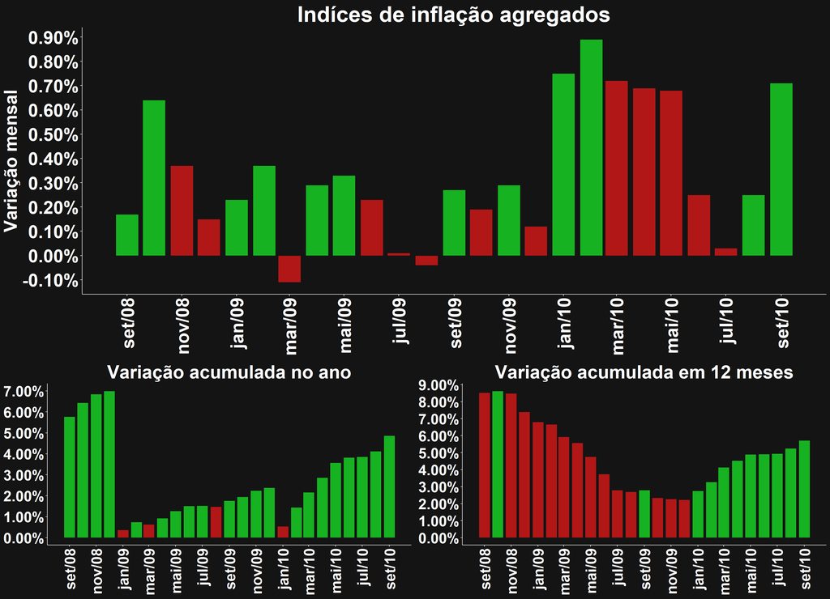

Índices selecionados para a média: IPCA, INPC e IGP-M.

# IPCA

O Indíce de Preços ao Consumidor Amplo (IPCA) variou 0.45% em setembro, valor superior ao mesmo período do ano anterior quando apresentou uma taxa de 0.24%. Com esse resultado o indíce acumula no ano uma variação positiva de 3.6%, e em 12 meses uma variação positiva de 4.7%.

|  | 09/2009 | 08/2010 | 09/2010 |
| --- | --- | --- | --- |
| Variação mensal | 0.24% | 0.04% | 0.45% |
| Variação acumulada no ano | 3.21% | 3.14% | 3.6% |
| Variação acumulada em 12 meses | 4.34% | 4.49% | 4.7% |

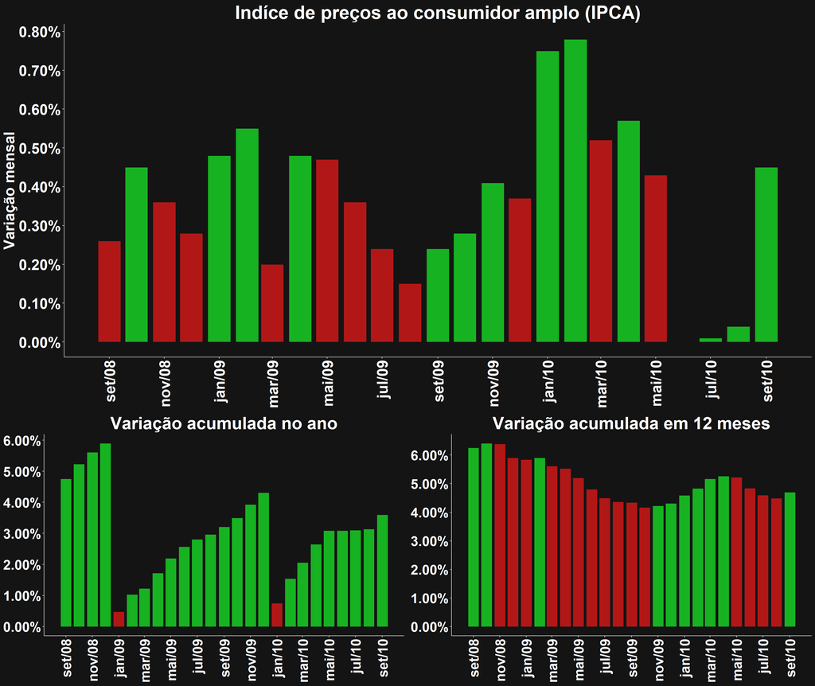

|  | Variação mensal | Variação acumulada no ano | Peso mensal |
| --- | --- | --- | --- |
| Alimentação e bebidas | 1.08% | 4.61% | 22.6% |
| Habitação | 0.4% | 3.38% | 13.31% |
| Artigos de residência | 0.46% | 3.15% | 4.18% |
| Vestuário | 0.45% | 3.85% | 6.76% |
| Transportes | 0.13% | 1.62% | 19.01% |
| Saúde e cuidados pessoais | 0.36% | 4.01% | 10.91% |
| Despesas pessoais | 0.34% | 5.3% | 10.39% |
| Educação | 0.08% | 6.07% | 7.26% |
| Comunicação | 0.04% | 0.1% | 5.59% |

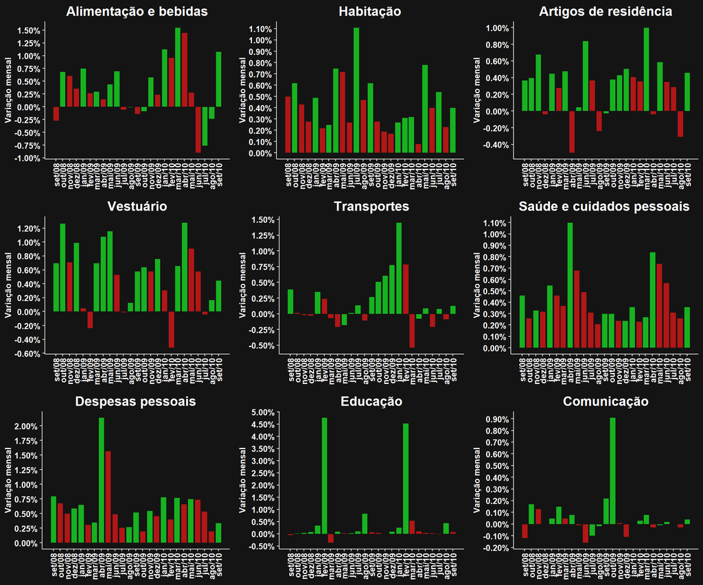

A nível de sub-itens os que mais influenciaram positivamente no resultado em relação ao seu peso foram Pão francês (2.93%%) e Alcatra (5.69%%), e negativamente Cebola (-24.55%%) e Batata-inglesa (-9.92%%).

|  | Variação mensal | Variação acumulada no ano | Peso mensal |
| --- | --- | --- | --- |
| Passagem aérea | 7.58% | -6.38% | 0.32% |
| Alcatra | 5.69% | 10.02% | 0.46% |
| Pão francês | 2.93% | 5.06% | 1.14% |
| Refeição | 0.49% | 6.11% | 4.42% |

|  | Variação mensal | Variação acumulada no ano | Peso mensal |
| --- | --- | --- | --- |
| Cebola | -24.55% | -38.36% | 0.12% |
| Tomate | -4.53% | -24.93% | 0.14% |
| Mamão | -7.23% | -20.25% | 0.1% |
| Batata-inglesa | -9.92% | -27.64% | 0.19% |

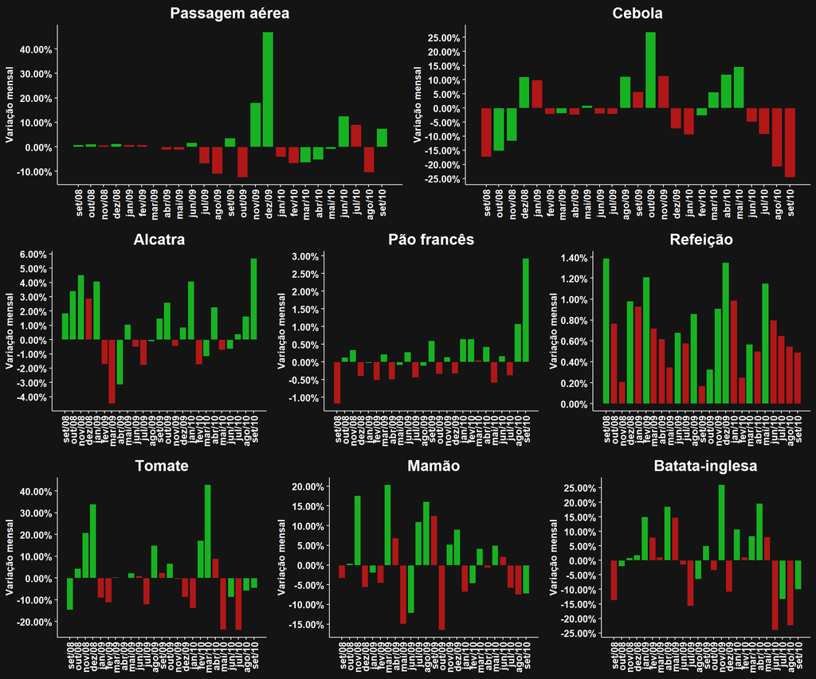

# INPC

O Indíce Nacional de Preços ao Consumidor (INPC) variou 0.54% em setembro, valor superior ao mesmo período do ano anterior quando apresentou uma taxa de 0.16%. Com esse resultado o indíce acumula no ano uma variação positiva de 3.79%, e em 12 meses uma variação positiva de 4.68%.

|  | 09/2009 | 08/2010 | 09/2010 |
| --- | --- | --- | --- |
| Variação mensal | 0.16% | -0.07% | 0.54% |
| Variação acumulada no ano | 3.24% | 3.24% | 3.79% |
| Variação acumulada em 12 meses | 4.45% | 4.29% | 4.68% |

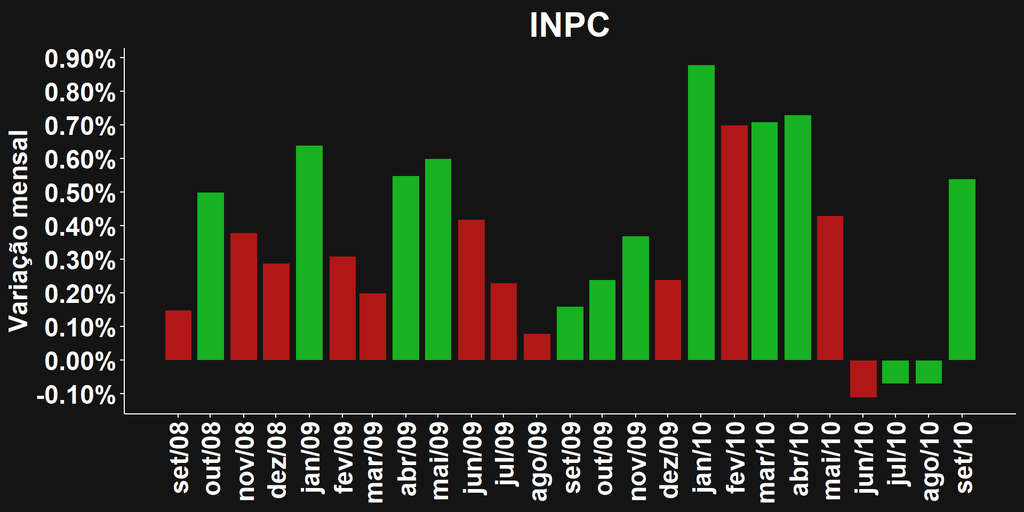

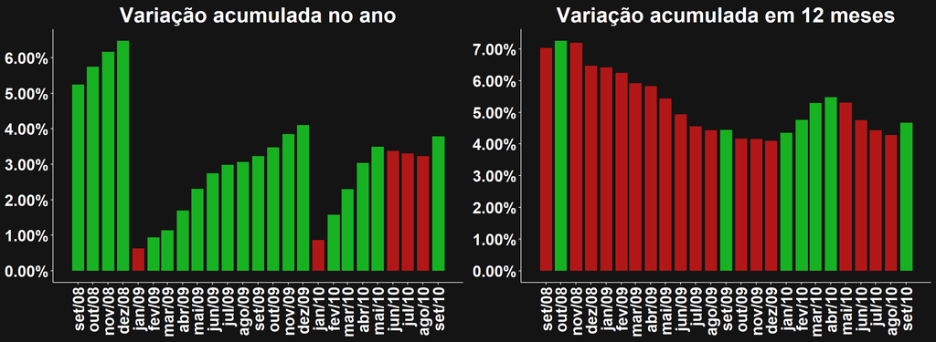

# IGP-M

O Indíce Geral de Preços de Mercado (IGP-M) variou 1.15% em setembro, valor superior ao mesmo período do ano anterior quando apresentou uma taxa de 0.42%. Com esse resultado o indíce acumula no ano uma variação positiva de 7.22%, e em 12 meses uma variação positiva de 7.77%.

|  | 09/2009 | 08/2010 | 09/2010 |
| --- | --- | --- | --- |
| Variação mensal | 0.42% | 0.77% | 1.15% |
| Variação acumulada no ano | -1.18% | 5.99% | 7.22% |
| Variação acumulada em 12 meses | -0.4% | 6.99% | 7.77% |

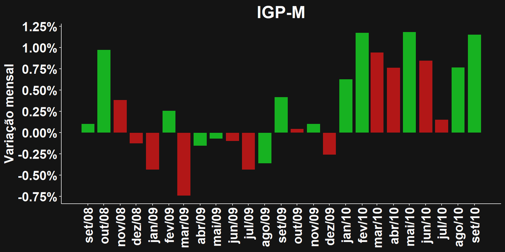

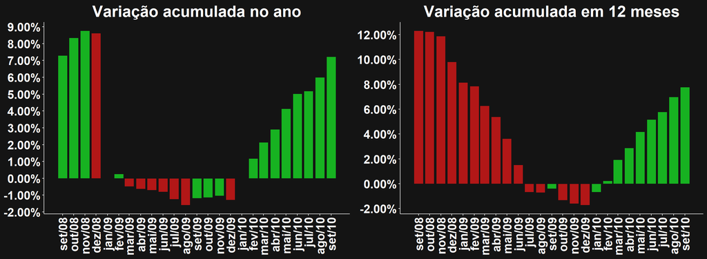

# IGP-DI

O Indíce Geral de Preços - Disponibilidade Interna (IGP-DI) variou 1.1% em setembro, valor superior ao mesmo período do ano anterior quando apresentou uma taxa de 0.25%. Com esse resultado o indíce acumula no ano uma variação positiva de 6.96%, e em 12 meses uma variação positiva de 7.95%.

|  | 09/2009 | 08/2010 | 09/2010 |
| --- | --- | --- | --- |
| Variação mensal | 0.25% | 1.1% | 1.1% |
| Variação acumulada no ano | -1.36% | 5.81% | 6.96% |
| Variação acumulada em 12 meses | -0.65% | 7.05% | 7.95% |

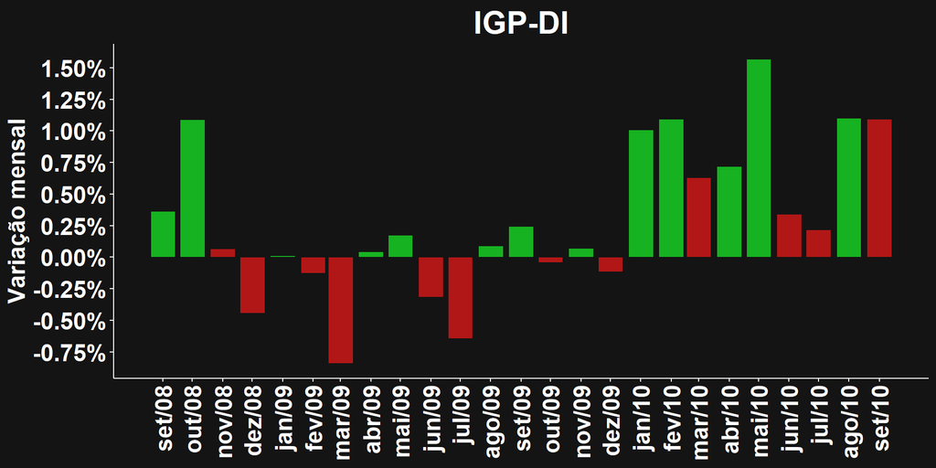

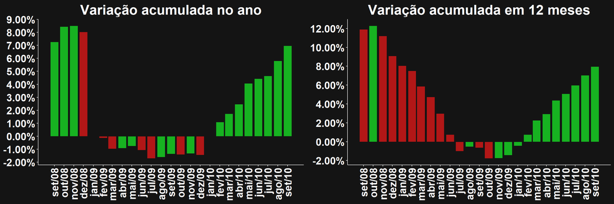

[output not shown]

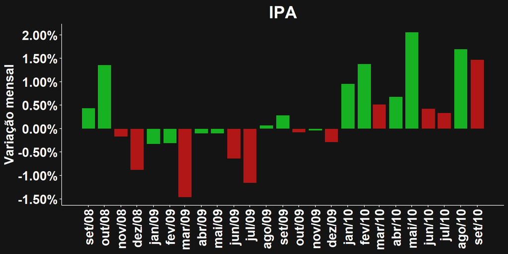

[figure not shown]

O Indíce de Preços ao Consumidor (IPC), integrante do IGP-DI com peso de 30%, apresentou variação de 0.46% em setembro, valor superior ao mesmo período do ano anterior quando apresentou uma taxa de 0.18%. Com esse resultado o indíce acumula no ano uma variação positiva de 2.49%, e em 12 meses uma variação positiva de 4.36%.

|  | 09/2009 | 08/2010 | 09/2010 |
| --- | --- | --- | --- |
| Variação mensal | 0.18% | -0.08% | 0.46% |
| Variação acumulada no ano | 2.56% | 2.02% | 2.49% |
| Variação acumulada em 12 meses | 5.02% | 4.06% | 4.36% |

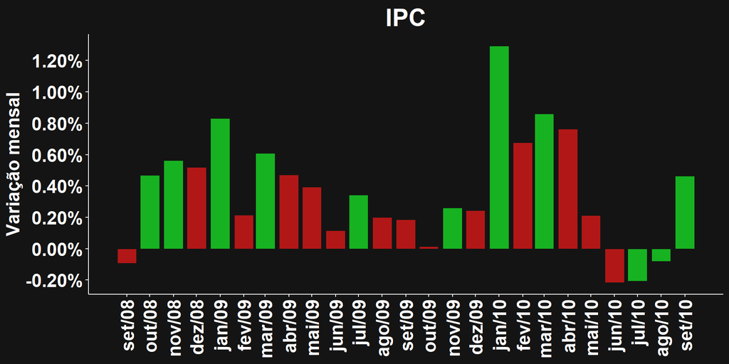

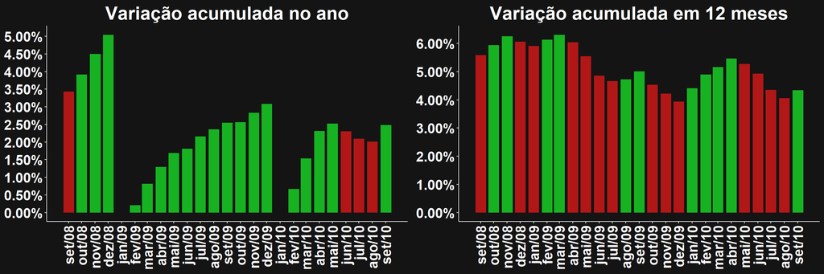

O Indíce Nacional de Custos de Construção (INCC), integrante do IGP-DI com peso de 10%, apresentou variação de 0.21% em setembro, valor superior ao mesmo período do ano anterior quando apresentou uma taxa de 0.15%. Com esse resultado o indíce acumula no ano uma variação positiva de 5.78%, e em 12 meses uma variação positiva de 6.94%.

|  | 09/2009 | 08/2010 | 09/2010 |
| --- | --- | --- | --- |
| Variação mensal | 0.15% | 0.14% | 0.21% |
| Variação acumulada no ano | 2.44% | 5.56% | 5.78% |
| Variação acumulada em 12 meses | 4.27% | 6.87% | 6.94% |

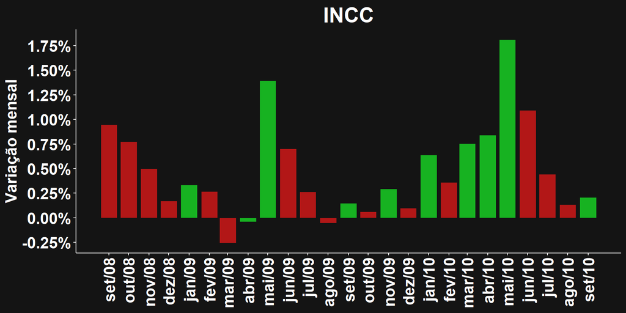

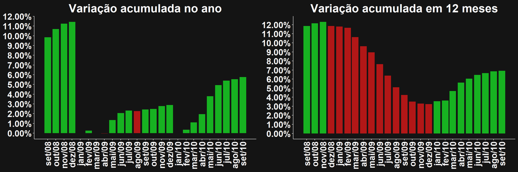

# Estatísticas

As estatísticas descritivas a seguir são feitas com base nos últimos 48 meses, e tem como objetivo possibilitar a avaliação do resultado observado em comparação aos períodos anteriores.

|  | Minimo | 1 Quartil | Mediana | Media | 3 Quartil | Maximo | Desvio Padrão |
| --- | --- | --- | --- | --- | --- | --- | --- |
| IPCA | 0% | 0.28% | 0.4% | 0.4% | 0.48% | 0.79% | 0.19% |
| INPC | -0.11% | 0.26% | 0.42% | 0.43% | 0.59% | 0.97% | 0.25% |
| IGP-M | -0.74% | 0.04% | 0.44% | 0.51% | 0.95% | 1.98% | 0.63% |
| IGP-DI | -0.84% | 0.09% | 0.37% | 0.51% | 1.06% | 1.89% | 0.63% |
| IPA | -1.46% | -0.05% | 0.42% | 0.54% | 1.28% | 2.29% | 0.9% |
| IPC | -0.21% | 0.21% | 0.37% | 0.4% | 0.61% | 1.29% | 0.32% |
| INCC | -0.26% | 0.25% | 0.42% | 0.57% | 0.79% | 2.02% | 0.51% |

Levando em consideração o desvio padrão de cada indíce, proporcionalmente os que mais se afastaram da média foram o IPA, o IGP-M e o IGP-DI.

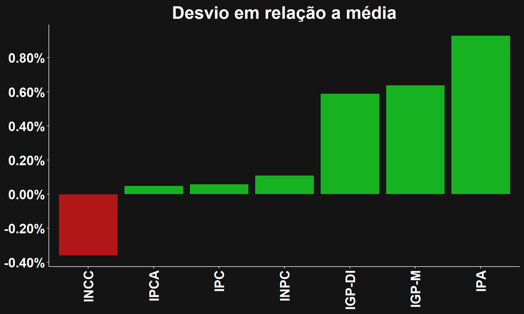

**João Victor Gomes**  
**jvg.santana@gmail.com**  
**[linkedin.com/in/jvictorgomes](https://www.linkedin.com/in/jvictorgomes/)**